# Trinvis databehandling

Christian Knudsen

2025-03-17

## trin 0

Her skal vi vise hvordan høstning af data gennem en API, bearbejdning og tilsidst visning af data kan foregår. Vi gør det trin for trin, klik på knappen for at gå til næste trin.

## trin 1

Først skal vi have indlæst biblioteker til hjælp for arbejdet.

```r
library(shiny)
library(shinyjs)
library(future)
library(promises)
library(tidyverse)
library(httr)
library(jsonlite)
library(magrittr)
```

## trin 2

Vi har fundet ud af at den interessante tabel fra Danmarks Statistik er “AKU410A”.

Metadata kan vi få fra dette endpoint:

```r
endpoint <- "http://api.statbank.dk/v1/tableinfo"
```

Og læser vi dokumentationen, kan vi finde ud af at vi skal have dette i “body” på et POST request:

```r
our_body <- list(lang = "da", table = "AKU410A")
```

## trin 3

Med vores endpoint og indholdet i “our_body”, kan vi hente metadata således:

```r
metadata <- POST(endpoint, body=our_body, encode = "json") %>%
  content() %>%
  fromJSON()
```

## trin 4

Det ser sådan ud:

```r
metadata
```

```
## $id
## [1] "AKU410A"
##
## $text
## [1] "Gennemsnitlig ugentlig arbejdstid i hovedjob"
##
## $description
## [1] "Gennemsnitlig ugentlig arbejdstid i hovedjob efter arbejdstid, alder, køn og tid"
##
## $unit
## [1] "Timer"
##
## $suppressedDataValue
## [1] "0"
##
## $updated
## [1] "2025-02-20T08:00:00"
##
## $active
## [1] TRUE
##
## $contacts
##                  name       phone       mail
## 1 Wendy Takacs Jensen +4551794714 wta@dst.dk
##
## $documentation
## $documentation$id
## [1] "fbcf1524-932a-4fcd-adb5-eb9c5387ce59"
##
## $documentation$url
## [1] "https://www.dst.dk/statistikdokumentation/fbcf1524-932a-4fcd-adb5-eb9c5387ce59"
##
##
## $footnote
## NULL
##
## $variables
##           id       text elimination  time
## 1 ARBEJDSTID arbejdstid       FALSE FALSE
## 2      ALDER      alder        TRUE FALSE
## 3       KOEN        køn        TRUE FALSE
## 4        Tid        tid       FALSE  TRUE
##                                                                                                                                                                                                                  values
## 1 002, 012, 022, Normal ugentlig arbejdstid, 1-95 timer, Faktisk ugentlig arbejdstid, 0-95 timer (inkl. fuld fravær i referenceugen), Faktisk ugentlig arbejdstid, 1-95 timer (mindst en times arbejde i referenceugen)
## 2                                                                                                                      TOT, 1524, 2534, 3544, 4554, 5564, Alder i alt, 15-24 år, 25-34 år, 35-44 år, 45-54 år, 55-64 år
## 3                                                                                                                                                                                       TOT, M, K, I alt, Mænd, Kvinder
## 4            2008, 2009, 2010, 2011, 2012, 2013, 2014, 2015, 2016, 2017, 2018, 2019, 2020, 2021, 2022, 2023, 2024, 2008, 2009, 2010, 2011, 2012, 2013, 2014, 2015, 2016, 2017, 2018, 2019, 2020, 2021, 2022, 2023, 2024
```

## trin 5

Vi vil gerne have en bestemt opgørelse af ARBEJDSTID, der matcher koden “022”. Vi vil gerne have alle værdier af ALDER. Og begge køn, men ikke totalen.

Og så er data opgjort for forskellige år. Vi vil gerne have dem alle.

Det giver disse variabler som vi beder om fra API’en:

```r
variables <- list(list(code = "ARBEJDSTID", values = I("022")),
                    list(code = "ALDER", values = I("*")),
                    list(code = "KOEN", values = c("M", "K")),
                    list(code = "Tid", values = I("*"))
  )
```

## trin 6

Det samlede “body” vi skal sende til API’en kommer derfor til at se således ud:

```r
data_body <- list(table = "AKU410A",
                  lang = "da",
                  format = "CSV",
                  variables = variables)
```

Og det kan vi nu sende med et POST-request til API’en. Først skal vi huske at ændre endpoint - for det er ikke metadata vi skal have, men data:

```r
endpoint <- "http://api.statbank.dk/v1/data"
```

## trin 7

```r
data <- POST(endpoint, body=data_body, encode = "json")
```

Nu står der forhåbentlig “200” ud for status når vi kigger på svaret:

```r
data
```

```
## Response [https://api.statbank.dk/v1/data]
##   Date: 2025-03-17 10:58
##   Status: 200
##   Content-Type: text/csv; charset=utf-8
##   Size: 22.5 kB
## ARBEJDSTID;ALDER;KOEN;TID;INDHOLD
## Faktisk ugentlig arbejdstid, 1-95 timer (mindst en times arbejde i referenceu...
## Faktisk ugentlig arbejdstid, 1-95 timer (mindst en times arbejde i referenceu...
## Faktisk ugentlig arbejdstid, 1-95 timer (mindst en times arbejde i referenceu...
## Faktisk ugentlig arbejdstid, 1-95 timer (mindst en times arbejde i referenceu...
## Faktisk ugentlig arbejdstid, 1-95 timer (mindst en times arbejde i referenceu...
## Faktisk ugentlig arbejdstid, 1-95 timer (mindst en times arbejde i referenceu...
## Faktisk ugentlig arbejdstid, 1-95 timer (mindst en times arbejde i referenceu...
## Faktisk ugentlig arbejdstid, 1-95 timer (mindst en times arbejde i referenceu...
## Faktisk ugentlig arbejdstid, 1-95 timer (mindst en times arbejde i referenceu...
## ...
```

## trin 8

Det skal vi have ekstraheret. Vi trækker “content” ud, og konverterer til csv:

```r
data <- data %>% content(type="text") %>% read_csv2()
```

```
## ℹ Using "','" as decimal and "'.'" as grouping mark. Use `read_delim()` for more control.
```

```
## No encoding supplied: defaulting to UTF-8.
```

Den første håndfuld linier i datasættet ser således ud:

```r
head(data)
```

```
## # A tibble: 6 × 5
##   ARBEJDSTID                                           ALDER KOEN    TID INDHOLD
##   <chr>                                                <chr> <chr> <dbl>   <dbl>
## 1 Faktisk ugentlig arbejdstid, 1-95 timer (mindst en … Alde… Mænd   2008    37.6
## 2 Faktisk ugentlig arbejdstid, 1-95 timer (mindst en … Alde… Mænd   2009    37.2
## 3 Faktisk ugentlig arbejdstid, 1-95 timer (mindst en … Alde… Mænd   2010    37.9
## 4 Faktisk ugentlig arbejdstid, 1-95 timer (mindst en … Alde… Mænd   2011    38.1
## 5 Faktisk ugentlig arbejdstid, 1-95 timer (mindst en … Alde… Mænd   2012    37.6
## 6 Faktisk ugentlig arbejdstid, 1-95 timer (mindst en … Alde… Mænd   2013    37.6
```

## trin 9

Vi er ikke interesserede i kolonnen “ARBEJDSTID”; den er alligevel den samme hver gang.

```r
data <- data %>%
  select(-ARBEJDSTID)
```

## trin 10

Nu kan vi lave et hurtigt plot. Faktisk ugentlig arbejdstid på y-aksen, årstallet for opgørelsen på x-aksen. Et plot for hvert køn, og en linie i grafen for hver aldersgruppe.

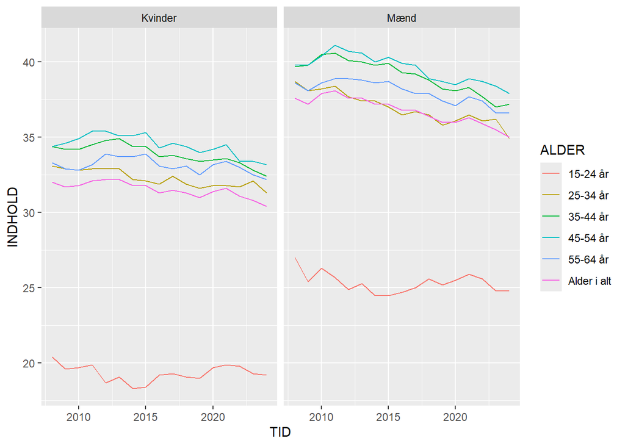

```r
data %>%
  ggplot(aes(x = TID, y = INDHOLD, colour = ALDER)) +
  geom_line() +
  facet_wrap(~KOEN)
```

## trin 11

Man kan pivotere dataframen, og få kønnene ud i hver sin kolonne. Det betyder at man kan beregne forskellen i arbejdstid mellem kønnene for de forskellige aldersgrupper:

```r
data %>%
  pivot_wider(names_from = KOEN, values_from = INDHOLD) %>%
  mutate(dif = Mænd - Kvinder)
```

```
## # A tibble: 102 × 5
##    ALDER         TID  Mænd Kvinder   dif
##    <chr>       <dbl> <dbl>   <dbl> <dbl>
##  1 Alder i alt  2008  37.6    32    5.6
##  2 Alder i alt  2009  37.2    31.7  5.50
##  3 Alder i alt  2010  37.9    31.8  6.1
##  4 Alder i alt  2011  38.1    32.1  6
##  5 Alder i alt  2012  37.6    32.2  5.4
##  6 Alder i alt  2013  37.6    32.2  5.4
##  7 Alder i alt  2014  37.2    31.8  5.4
##  8 Alder i alt  2015  37.2    31.8  5.4
##  9 Alder i alt  2016  36.8    31.3  5.50
## 10 Alder i alt  2017  36.8    31.5  5.3
## # ℹ 92 more rows
```

## trin 12

Den forskel kan man så plotte, og se hvordan det udvikler sig:

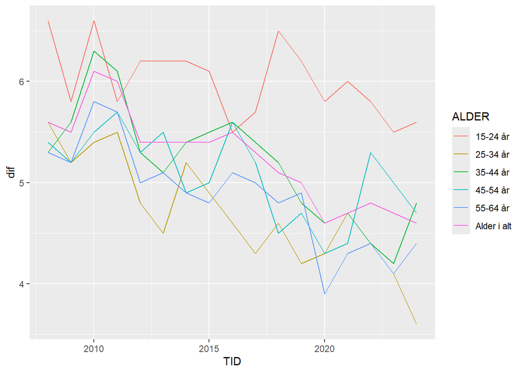

```r
data %>%
  pivot_wider(names_from = KOEN, values_from = INDHOLD) %>%
  mutate(dif = Mænd - Kvinder) %>%
  ggplot(aes(x=TID, y = dif, colour = ALDER)) +
  geom_line()
```

Det ser overordnet ud som om det bevæger sig den rette vej. Ligestilling på denne parameter er en forskel på 0, og selvom det varierer en del, er den overordnede tendens faldende.

## trin 13

vi kan dykke ned i tallene og se på “Alder i alt”

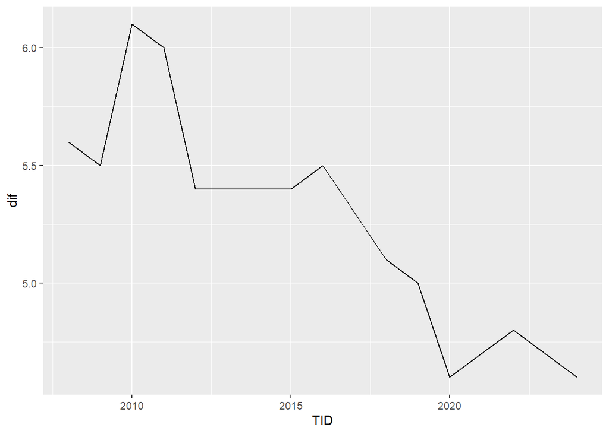

```r
data %>%
  pivot_wider(names_from = KOEN, values_from = INDHOLD) %>%
  mutate(dif = Mænd - Kvinder) %>%
  filter(ALDER == "Alder i alt") %>%
  ggplot(aes(x=TID, y = dif)) +
  geom_line()
```

Der er klart tale om at det totalt går i den rigtige retning.

## trin 14

men hvornår er vi i mål?

Vi laver samme beregninger som før. Og så laver vi en lineær model, trækker koefficienterne ud, og regner ud hvornår forskellen i Faktisk ugentlig arbejdstid, når 0 og ligestillingen er opnået på dette punkt:

```r
i_mål <- data %>%
  pivot_wider(names_from = KOEN, values_from = INDHOLD) %>%
  mutate(dif = Mænd - Kvinder) %>%
  filter(ALDER == "Alder i alt") %>%
  lm(formula = dif~TID, data = .) %>%
  coef() %>%
  { -.[["(Intercept)"]] / .[["TID"]] } %>%
  round()
```

Det gør vi i år 2081. Så jeg når ikke at se det ske.

## trin 15

Men hvornår har mændene så deres sidste arbejdsdag? Hvornår skal de holde fri, for at kønnene kan komme til at bidrage lige meget til arbejdsmarkedet?

Det er let at beregne. Hvis mændene arbejder 35 timer om ugen, og kvinderne 31, så kan mændene holde fri efter 31/35*365 = 323.2857143 dage.